# Course6-Project

Arind

July 19, 2018

## Overview

In this course project of the statistical inference class from Coursera, we investigate the **Exponential Distribution** in **R** and aply the **Central Limit Theorem** to a thousand mean simulations. The formula for exponential distribution is given below.
$$f(x) = \lambda e^{-\lambda x},\ where\ \ \lambda = rate\ \ paramenter$$
*Both the theoritical mean($\mu$) and the standard deviation($\sigma$) for this distribution is $1/\lambda$.*

The project illustrates via simulation and associated explanatory text the properties of the distribution of the mean of 40 exponentials and simulating it 1000 times.

## Simulations

Here, A 1000 simulations, each with 40 samples of an exponential distribution. The mean and variance of of those 40 samples will be calculated and compared to the theoretical estimates. **Central limit theorem** states that as the number in the sample increases or the number of simulations increase, the sample mean and variance should more accurately represent the theoretical estimate.

```r
set.seed(99)
lambda <- 0.2 # the rate parameter lambda as instructed
n <- 40 # no. of exponentials
sim <- 1000 # no. of simulations
```

```r
sim.mean <- sim.var <- NULL
for(i in 1:sim) {
  sim.mean <- c(sim.mean, mean(rexp(n,lambda))) # means of each simulations
}
sim.data <- data.frame("simulations" = 1:sim, sim.mean)
```

Next, the average of the mean and the variance across all 1000 simulations is calculated.

```r
t.mean = 1/lambda
p.mean = mean(sim.mean)
t.var = (1/lambda)^2/n
p.var = var(sim.mean)
```

## Sample Mean versus Theoretical Mean

From CLT, we know the theoretical mean of an exponential distribution is 1 / lambda. Given lambda of 0.2, the theoretical mean is 5 (theoretical mean = 1 / 0.2). In comparison, calculation below shows that the simulated mean is 5.0148085, which conforms to the expected theoretical mean value as provided by the CLT. We can plot the above findings as.

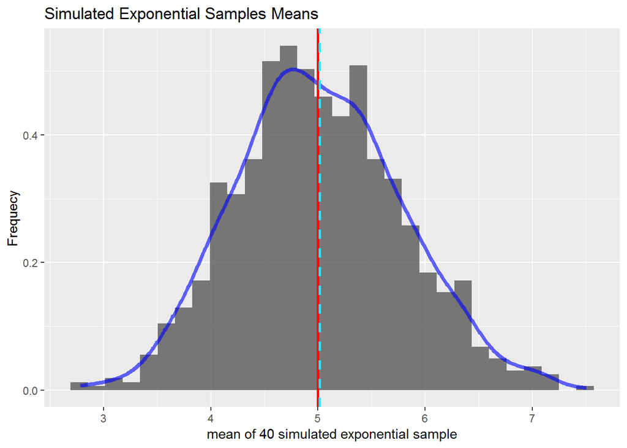

```r
library(ggplot2)
ggplot(sim.data, aes(x = sim.mean)) +
  geom_histogram(aes(y = ..density..), alpha = 0.8) +
  stat_density(geom = "line", color = "blue", size =1.5, alpha = 0.6) +
  geom_vline(xintercept = t.mean, color="red", size=1) +
  geom_vline(xintercept = p.mean, color="cyan", size=1, linetype=2) +
  labs(x="mean of 40 simulated exponential sample", y= "Frequecy",
         title="Simulated Exponential Samples Means")
```

## Sample Variance versus Theoretical Variance

From CLT, we know the theoretical standard deviation of the mean is $1/(\lambda * \sqrt n)$ and the variance is $1/(\lambda ^2 *n)$.

- Theoritical variance is 0.625
- Sample variance of the sample is 0.5929536

## Distribution

To check if the distributin is normal or not, we plot the Q-Q Normal plot.

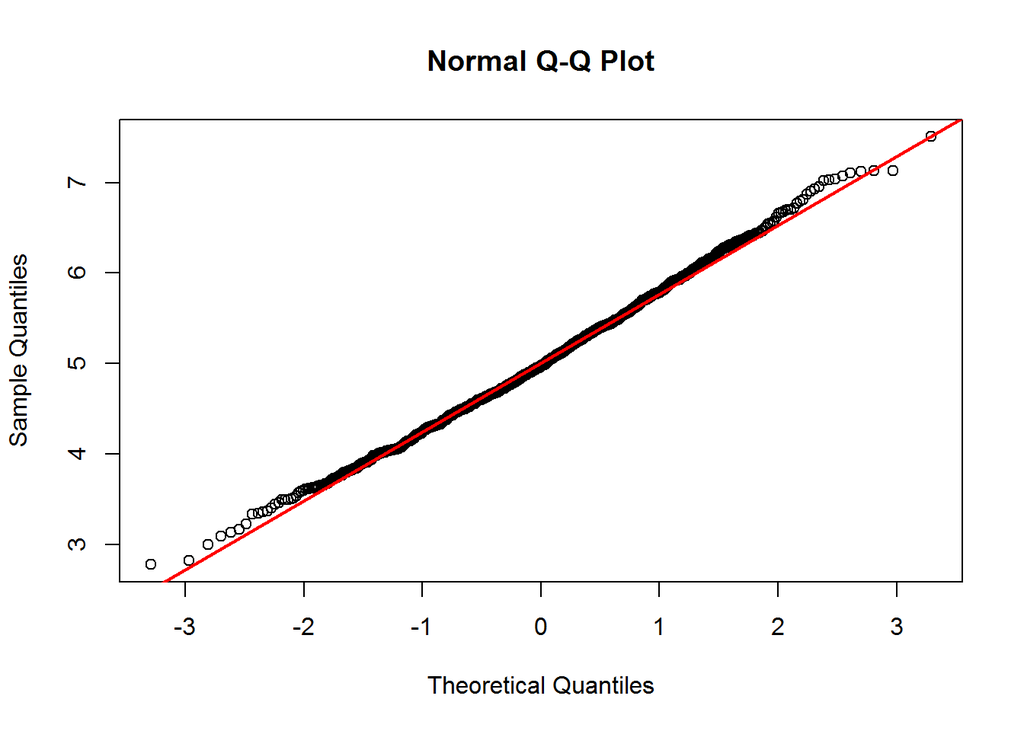

```r
qqnorm(sim.mean)
qqline(sim.mean, col = "red", lwd = 2)
```

From the Q-Q Plot it is evident that the distribution is nearly normal.